# Part I - (Loan Data from Prosper)

#### Loan Status vs StatedMonthlyIncome

This is check if the higher you earn, the more likey you are able to completed a loan payment or otherwise

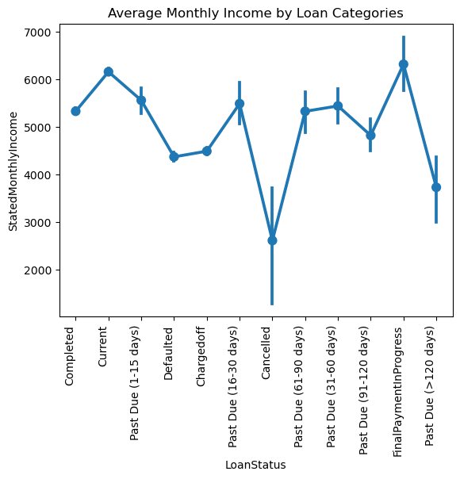

```python
# pointplot
sb.pointplot(data=loan_data, x='LoanStatus', y='StatedMonthlyIncome')
plt.xticks(rotation=90, ha='right', fontsize=10)
plt.title('Average Monthly Income by Loan Categories');
```

From the plot above, the chargedoff, completed, current and defaulted loan have average values with close to no uncertainity around the estimated stated monthly income for the categories. We can say that the average monthly income for completed loans is around $5200 while for defaulted loans is around $4500. A point of interest is why the average monthly income for borrowers in the 'Current' and 'FinalPaymentInProgress' categories is quite high (above $6000).

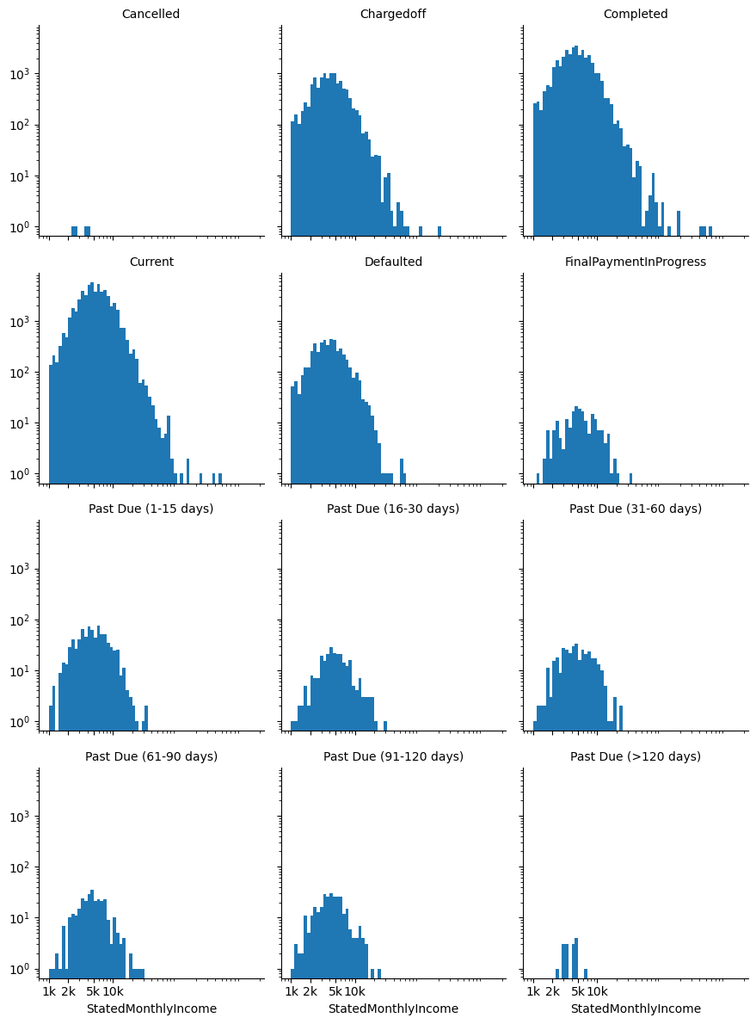

```python
bins = 10 ** np.arange(3, 6.2+0.05, 0.05)

g = sb.FacetGrid(data=loan_data, col='LoanStatus', col_wrap=3)
g.map(plt.hist, 'StatedMonthlyIncome', bins=bins)
g.set_titles('{col_name}')

plt.xscale('log')
plt.xticks([1e3,2e3,5e3,1e4], ['1k','2k','5k','10k'])
plt.yscale('log')
```

```python
Generally, the distribution of the statedmonthly income for the loan status categories follow almost similar distribution.
For the completed loans, majority of the monthly income of borrowers is between $2,000 and $5,000. This trend is quite similar
for other categories such as defaulted loans and past-due loans(1-15days).
```

#### Which Occupation earns more monthly income?

This is to explore the occupation with the highest monthly income and possibly target lending to them.

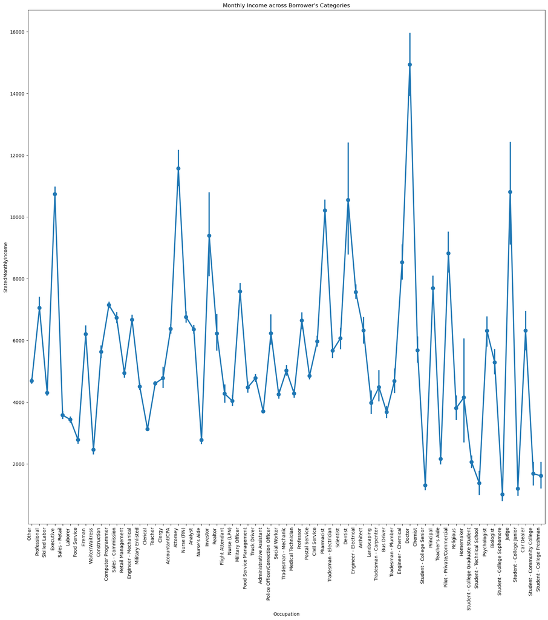

```python
plt.figure(figsize=[20,20])

sb.pointplot(data=loan_data, x='Occupation', y='StatedMonthlyIncome')
plt.xticks(rotation=90, ha='right', fontsize=10)
plt.title("Monthly Income across Borrower's Categories");
```

#### Is employment status a deciding factor for loan repayment?

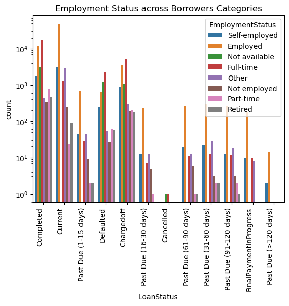

```python
sb.countplot(data=loan_data, x='LoanStatus', hue='EmploymentStatus')
plt.xticks(rotation=90, ha='right', fontsize=10)
plt.yscale('log')
plt.title("Employment Status across Borrowers Categories")
```

```python
From the plot, full-time employees are the highest loan defaulters and completers.
```

### Did you observe any interesting relationships between the other features (not the main feature(s) of interest)?

> I decided to look at factors behind the ProsperRating so when compared with CreditScoreRangeUpper, there was a positive correlation. I want to imply that a good or high credit score increases the likelihood of being qualified for a loan with higher risk or rate involved.

## Multivariate Exploration

### Borrowing Patterns: Look at the trend by quarter, amount and reasons for the loans

I will investigate further by looking at borrowing patterns across the listed categories by loan origination quarter. Since the loanOriginalQuarter column contains both quarter and year, it will be splitted into two columns by quarter and year.

```python
loan_data[['LoanOriginationQuarter_', 'LoanOriginationYear']] = loan_data['LoanOriginationQuarter'].str.split(' ', expand=True)
```

```python
# set the quarter order
ordinal_var_dict = {'LoanOriginationQuarter_': ['Q1', 'Q2', 'Q3', 'Q4']}

convert_ordinal_dtype(ordinal_var_dict)
```

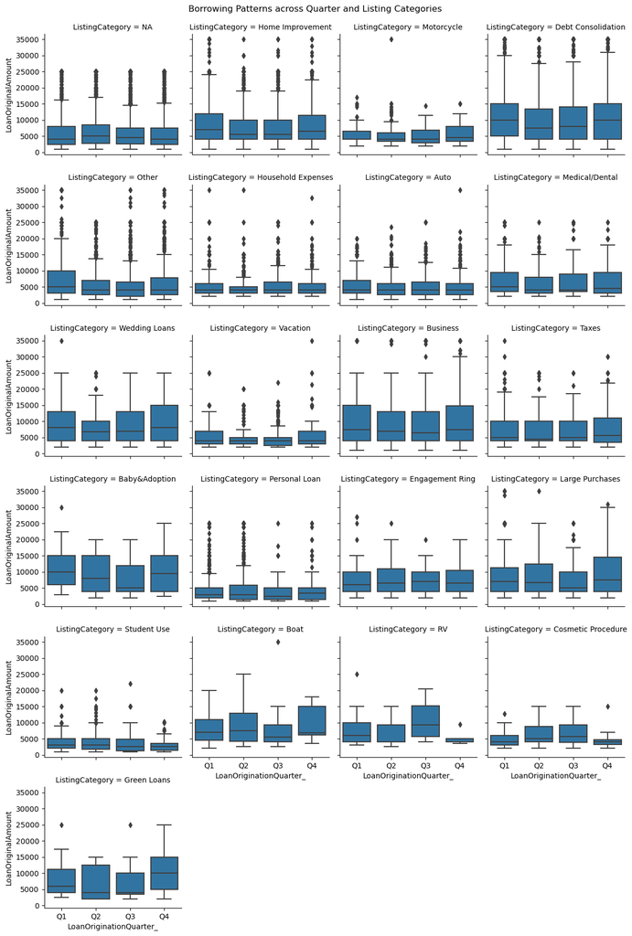

```python
g = sb.FacetGrid(data=loan_data, col = 'ListingCategory', col_wrap=4);
g.map(sb.boxplot, 'LoanOriginationQuarter_', 'LoanOriginalAmount');
g.fig.subplots_adjust(top=0.95);
g.fig.suptitle("Borrowing Patterns across Quarter and Listing Categories");
```

#### Do higher/lower income earners defaults more?

Explore the relationship between incomeRange, loanStatus and TotalProsperLoans.

Because we have a lot of categories in the Loan status column. I want to focus on completed and defaulted loans for this analysis. Therefore, I will create a new column 'IsDefault'.

```python
# categorize loans
def isLoanDefault(status):
    if status == 'Completed':
        val = 'no'
    elif status == 'Defaulted':
        val = 'yes'
    else:
        val = 'maybe'
    return val
```

```python
loan_data['IsLoanDefault'] = loan_data['LoanStatus'].apply(isLoanDefault)
```

```python
loan_data['IncomeRange'].value_counts()
```

```
$25,000-49,999    32192
$50,000-74,999    31050
$100,000+         17337
$75,000-99,999    16916
Not displayed      7741
$1-24,999          7274
Not employed        806
$0                  621
Name: IncomeRange, dtype: int64
```

```python
loan_data['TotalProsperLoans'].value_counts()
```

```
0    91853
1    15538
2     4540
3     1447
4      417
5      104
6       29
7        8
8        1
Name: TotalProsperLoans, dtype: int64
```

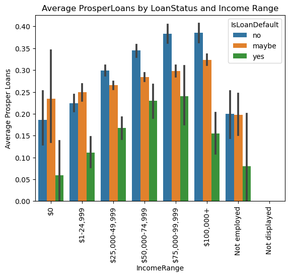

```python
sb.barplot(data=loan_data, x='IncomeRange', y='TotalProsperLoans',
            hue='IsLoanDefault', dodge=True)
plt.xticks(rotation = 90)
plt.ylabel('Average Prosper Loans')
plt.title('Average ProsperLoans by LoanStatus and Income Range');
```

Across the Income range based on the average number of prosper loans, there is a higher number of completed loans. The plot shows that as income increases so is the average number of prosper loans collected and completed increases except for the unidentified income ranges.

### Do prosperrating really describe the risk and returns in terms of estimated yield and returns and loan term?

```python
Since ProsperRatings were used for loans after July 2009. Therefore, this analysis will be aimed at the loan dataset
after July 2009
```

```python
# loans after July 2009
postloan_072009 = loan_data[loan_data['LoanOriginationDate'].dt.to_period('M') >= '2009-07']
```

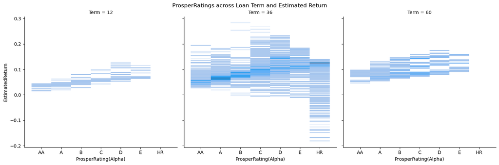

```python
g = sb.displot(data=postloan_072009, x='ProsperRating(Alpha)', y='EstimatedReturn', col='Term', color=base_color)
g.fig.subplots_adjust(top=0.8);
g.fig.suptitle('ProsperRatings across Loan Term and Estimated Return', fontsize=15);
```

### Talk about some of the relationships you observed in this part of the investigation. Were there features that strengthened each other in terms of looking at your feature(s) of interest?

> The ProsperRating strengthened the estimated return as it proves to be a useful measure in categorizing the loan type for investors. I also noticed that as income increases so does the number of prosper loans received by borrowers increases.

### Were there any interesting or surprising interactions between features?

> Most people request for loans for debt consolidation across the year. An interesting find is that people take out high loans to purchase Recreation Vehicles during the third Quarter of the year and also for Weddings in the last quarter of the year.